[figure not shown]

# Linear Regression: our first algorithm

MY202 · Lab 3

Jonas Weinert

Department of Methodology | London School of Economics and Political Science

29 October 2026

## Lab overview

| Part | Topic | Functions | Mode | Time |
| --- | --- | --- | --- | --- |
|  | Setup: notebook lines 24–72 |  | together | 2 min |
|  | Concept: warm-up, then our first algorithm | `~`, `linear_reg()`, `fit()` | slides | 15 min |
| 1 | Exploring the data | `ggplot`, `geom_histogram`, `geom_boxplot` | your turn | 12 min |
| 2 | Hypothesis testing | `extract_fit_engine`, `summary`, `~ .` | together | 8 min |
| 3 | The machine learning approach | `initial_split`, `training`, `testing`, `augment`, `metric_set` | together | 18 min |
| 4 | Where do we make errors? | `.pred`, `.resid`, `geom_hline` | together | 8 min |
| 5 | Lasso | `penalty`, `mixture`, `set_engine`, `tidy` | step 1 together, then your turn | 22 min |

**Together**: we type the code line by line, the slide explains each piece, and a notebook line number says where to type. **Your turn**: a timer, tasks and a syntax sheet, then the solutions.

# Our first algorithm

Concept

Three warm-up questions · what a model is · how a line is chosen · how we judge it

## Warm-up 1 of 3

Concept1 · EDA2 · Hypothesis3 · ML4 · Residuals5 · LassoWrap-up

A rule predicts a grade as **10 + 0.5 × hours of study**. A student studies 4 hours a week. What grade does the rule predict?

**A**10.5

**B**12

**C**14

**D**I'm not sure how to read the rule

**B.** 10 + 0.5 × 4 = 10 + 2 = 12. Reading a rule like this is all the arithmetic we need today.

## Warm-up 2 of 3

Concept1 · EDA2 · Hypothesis3 · ML4 · Residuals5 · LassoWrap-up

How does linear regression choose *which* line to draw through the points?

**A**The line that passes through the most points

**B**The line whose gaps to the points add up to zero

**C**The line whose squared gaps to the points are as small as possible

**D**I've never thought about it

**C.** Ordinary least squares: the smallest sum of squared residuals. B is a trap: many bad lines have gaps that add up to zero.

## Warm-up 3 of 3

Concept1 · EDA2 · Hypothesis3 · ML4 · Residuals5 · LassoWrap-up

A house-price model has R² = 0.65. What does that mean?

**A**65% of the model's predictions are correct

**B**The features (such as floor area) explain 65% of the variation in house prices

**C**The model's error is 65% smaller than a perfect model's

**D**I haven't met R² before

**B.** R² is about variation, not about how many predictions are "right": a regression prediction is almost never exactly right. The remaining 35% is left in the residuals.

## What is a model?

Concept1 · EDA2 · Hypothesis3 · ML4 · Residuals5 · LassoWrap-up

A model is a **rule** that turns inputs into a prediction. Made up for now: a grade from study hours and past failures.

The rulegrade = 10 + 0.5 × hours − 2 × failures

One student6 hours a week, 1 past failure

Plug in10 + 0.5 × 6 − 2 × 1 = 10 + 3 − 2

Prediction= 11

Actual grade13

Residual13 − 11 = +2 the rule guessed 2 points too low

Where do 10, 0.5 and −2 come from? The numbers in the rule are its **coefficients**. Someone has to choose them.

An **algorithm** is a recipe for choosing them from data. Today’s: **ordinary least squares**, built from scratch in the next five slides.

## Which line is best?

Concept1 · EDA2 · Hypothesis3 · ML4 · Residuals5 · LassoWrap-up

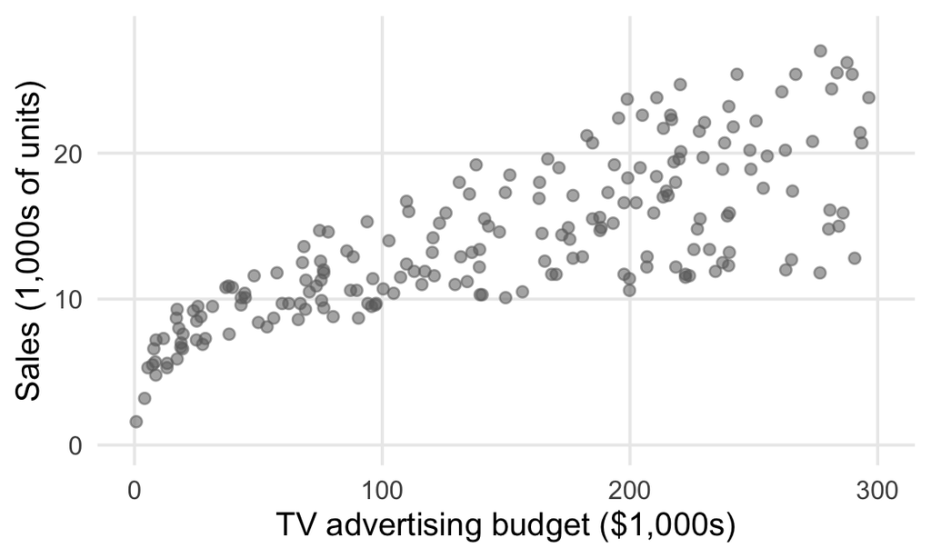

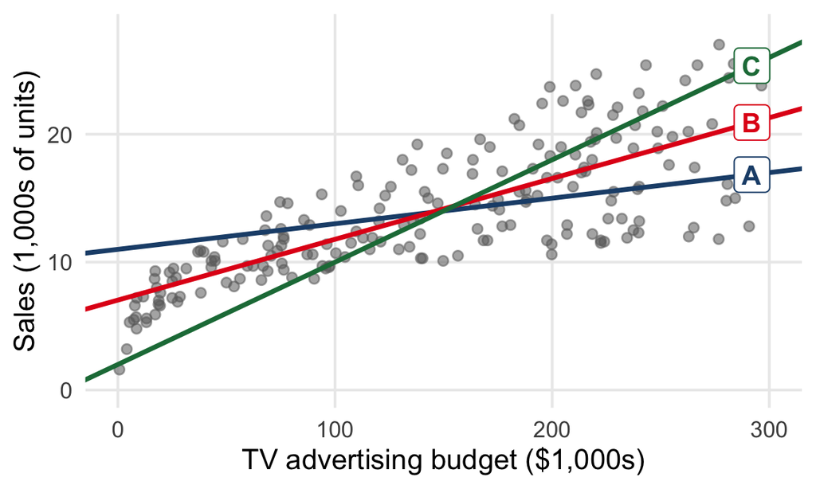

200 markets: what was spent on TV ads, and how much was sold. We want a line that predicts **sales** from a **budget**.

Vote: A, B or C?

The harder question Most pick B. But *why*? A computer can’t choose a line without a **number** that says how wrong a line is.

## How wrong is a line? Residuals

Concept1 · EDA2 · Hypothesis3 · ML4 · Residuals5 · LassoWrap-up

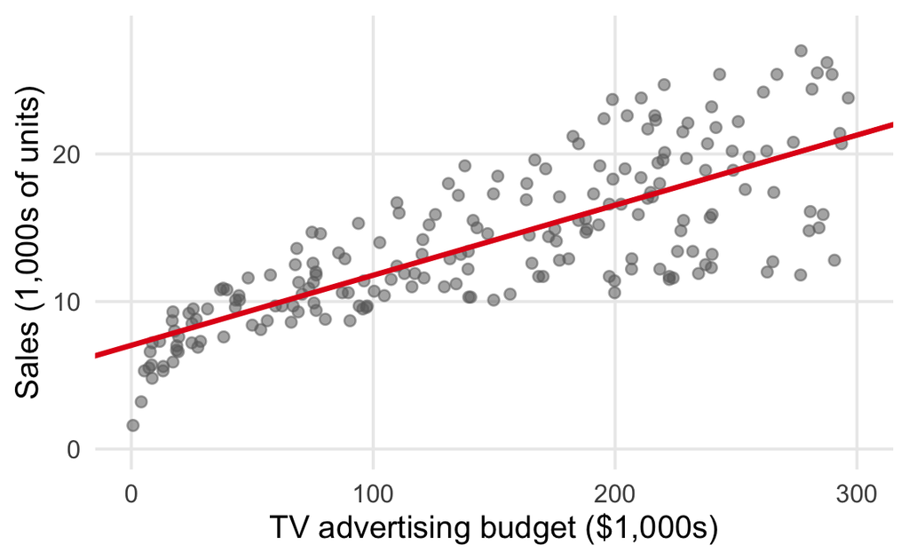

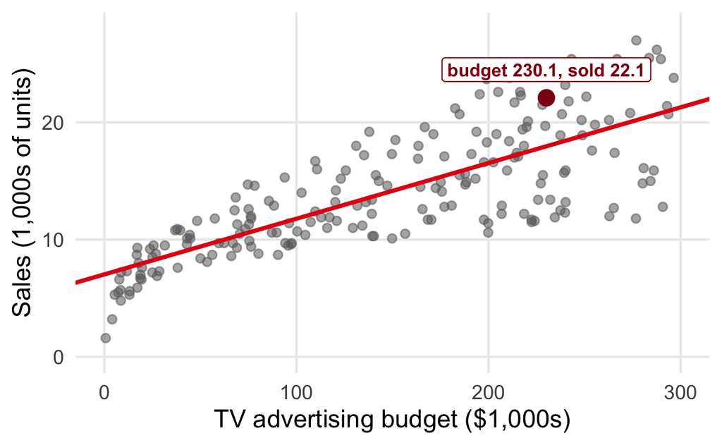

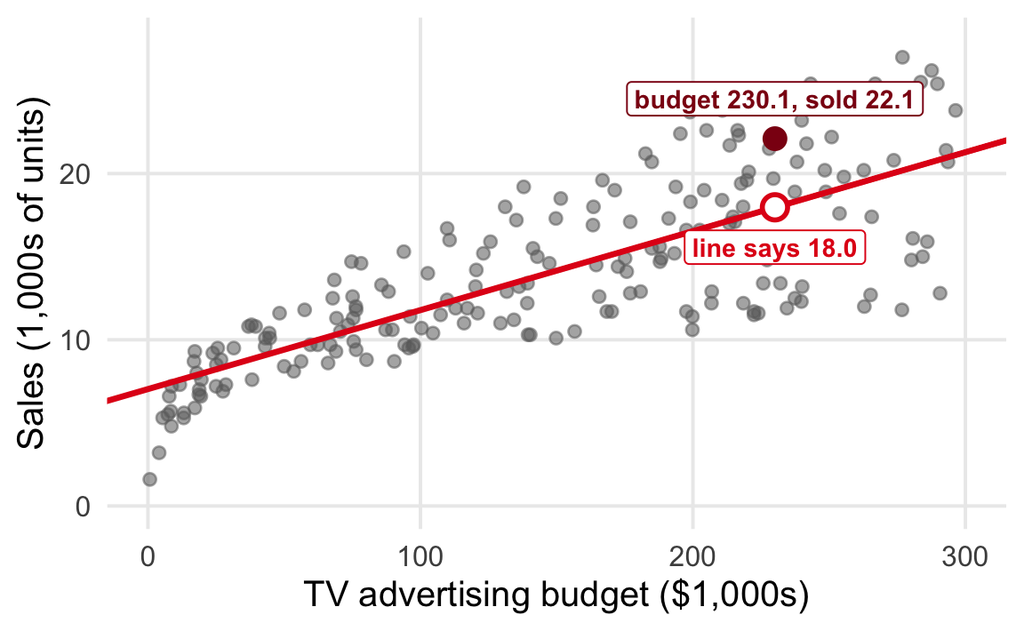

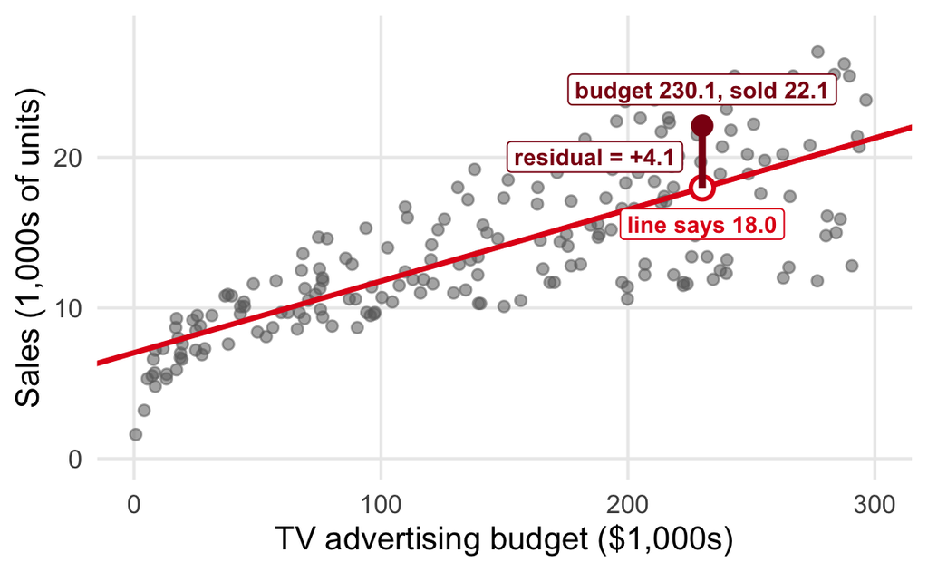

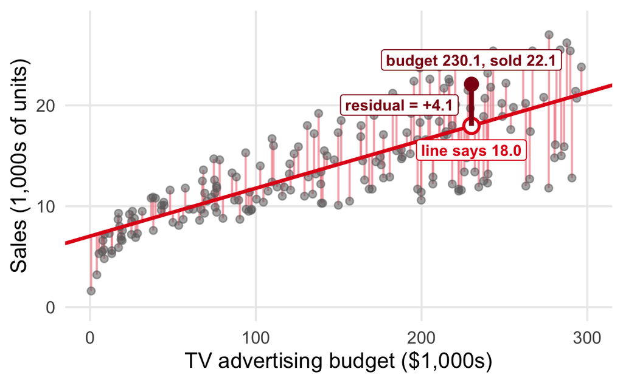

One marketbudget 230.1, sold 22.1

The line sayssales ≈ 18.0

Residual22.1 − 18.0 = +4.1

Residual = actual − predicted Positive: the line guessed too low. Negative: too high.

200 markets, 200 residuals How do we turn 200 numbers into **one score** for the line?

## Add them up?

Concept1 · EDA2 · Hypothesis3 · ML4 · Residuals5 · LassoWrap-up

Just add the residuals

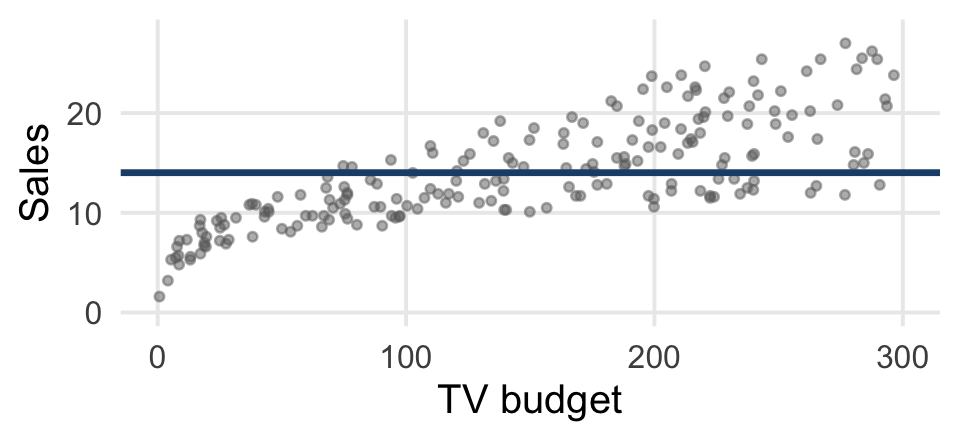

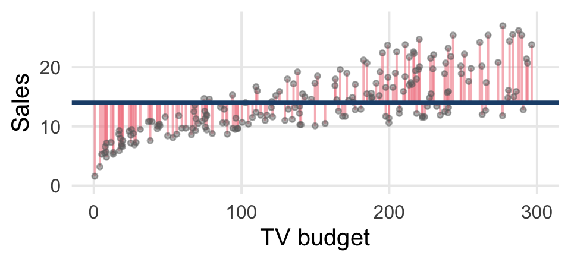

A flat line at the average is clearly bad, yet its residuals add up to **exactly 0**: positives and negatives cancel.

Square first, then add

Market 1+4.1 ² = 17.1

Market 2+1.3 ² = 1.6

Market 5-2.7 ² = 7.4 negative, but its square is positive

All 200RSS = 2,103 residual sum of squares

Flat line: 5,417. Line B: 2,103. **Lower is better**, and one miss of 4 now costs more than two misses of 2.

## Try every line: the bowl

Concept1 · EDA2 · Hypothesis3 · ML4 · Residuals5 · LassoWrap-up

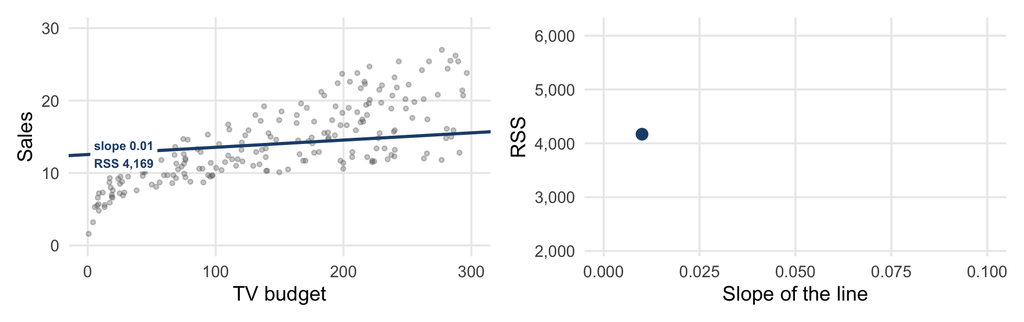

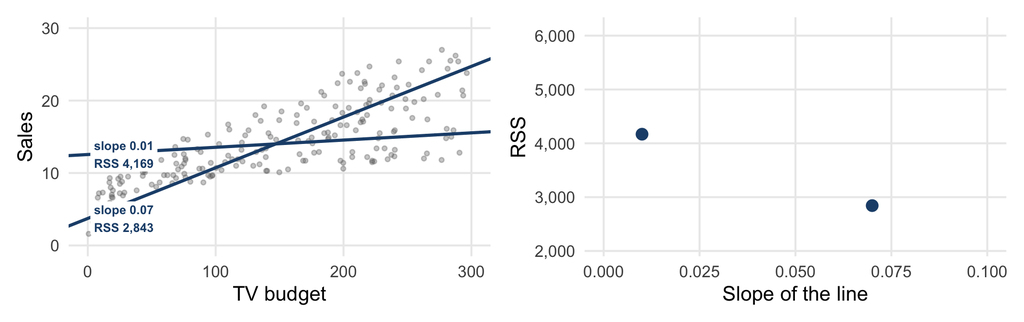

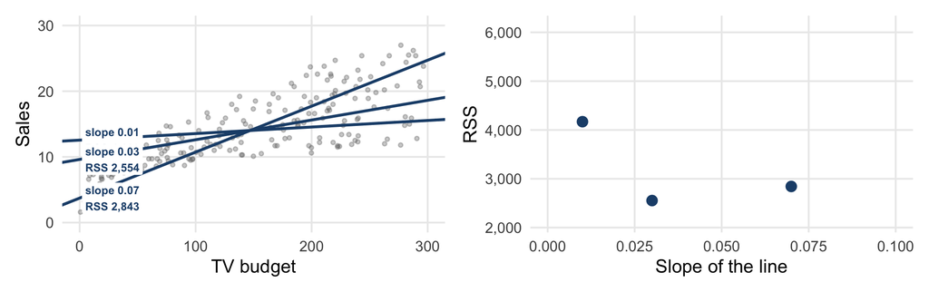

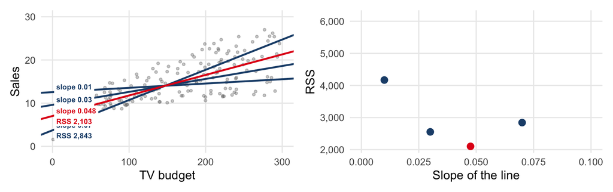

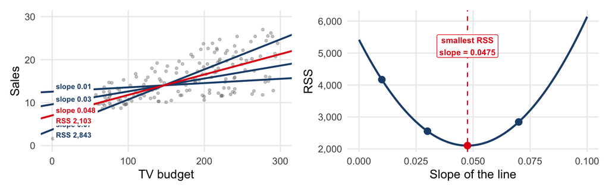

Ordinary least squares (OLS) The line with the **smallest sum of squared residuals**. That’s the whole algorithm.

You don’t have to try every line For linear models a formula jumps straight to the bottom of the bowl. Later models really do walk downhill.

## The equation, piece by piece

Concept1 · EDA2 · Hypothesis3 · ML4 · Residuals5 · LassoWrap-up

ŷ = β₀ + β₁ · x

1. **The prediction.** The hat means “our estimate”, as opposed to the real *y*. Spoken “y-hat”.
2. **The intercept.** The prediction when *x* is 0.
3. **The slope.** The change in the prediction when *x* goes up by **one unit**.
4. **The feature.** The input we know. Also called predictor or independent variable.

Fitted linesales = 7.03 + 0.0475 × TV every extra $1,000 on TV adds about 48 units

Market 1TV = 230.1

Plug in7.03 + 0.0475 × 230.1 = 7.03 + 10.94

Predictionŷ = 18.0 the "line says" number from three slides ago

## More than one feature

Concept1 · EDA2 · Hypothesis3 · ML4 · Residuals5 · LassoWrap-up

ŷ = β₀ + β₁ x₁ + β₂ x₂ + … + βₚ xₚ

1. **One coefficient per feature.** Each β: the change in the prediction when *that* feature rises by 1, **with the others held fixed**.
2. **Still a line**, just in more dimensions. Same squared residuals, same bowl, same bottom.
3. *p* features, *p* slopes. Today: 30 columns, 67 coefficients.

Why 67 coefficients from 30 features? Text columns become 0/1 columns: `higher` yes/no becomes `higheryes` (1 for yes). A feature with 4 categories gets 3 such columns, one for each category except the first, the **reference**.

## How good is the line? R²

Concept1 · EDA2 · Hypothesis3 · ML4 · Residuals5 · LassoWrap-up

R² = 1 − RSS / TSS

1. **Share of the variation explained**: 0 is no better than the mean, 1 is a perfect fit.
2. Squared residuals of **our** line.
3. Squared residuals of the **flat line** at the mean.

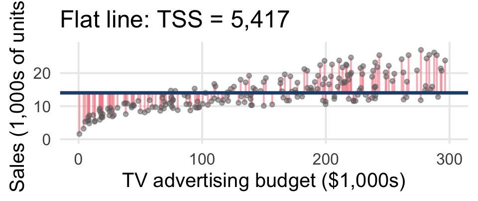

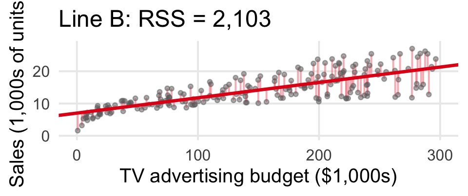

Flat lineTSS = 5,417

Line BRSS = 2,103

Divide1 − 2,103 / 5,417 = 1 − 0.39

R²= 0.61 TV explains 61% of the variation

## How good is the line? RMSE

Concept1 · EDA2 · Hypothesis3 · ML4 · Residuals5 · LassoWrap-up

RMSE = √ mean( residual² )

1. **Root mean squared error**: the typical miss, in the **units of the outcome**. An RMSE of 3 on a 0–20 grade means a typical prediction is about 3 points off.
2. Average the squared residuals, then take the square root to undo the squaring.

AdvertisingRSS = 2,103 over 200 markets

Mean2,103 / 200 = 10.5 the average squared residual

Root√10.5 = 3.2

RMSE= 3.2 thousand units a typical prediction is about 3200 units off

## The same thing in code

Concept1 · EDA2 · Hypothesis3 · ML4 · Residuals5 · LassoWrap-up

linear_reg() |> fit(final_grade ~ higher, data = students)

1. **Which kind of model.** A linear one. On its own this fits nothing: it’s an empty recipe.
2. **Run the algorithm.** Find the coefficients with the smallest RSS.
3. **The outcome**, *y*: what we want to predict. Left of the tilde.
4. **The tilde** reads as “explained by” or “as a function of”. It turns the two sides into a **formula**.
5. **The feature(s)**, *x*: right of the tilde. Several: `higher + failures`. Everything else in the table: `.`
6. **Which table** the columns live in.

In words: “fit a linear model of `final_grade` explained by `higher`, using the `students` table.”

# Exploring the data

Part 1

649 students · 30 features · one grade

## Meet the data

Concept1 · EDA2 · Hypothesis3 · ML4 · Residuals5 · LassoWrap-up

**649**students from two Portuguese secondary schools. One row each.

**30**features: who they are, how they study, how they live

**0–20**`final_grade`, the outcome. Mean 11.9, median 12.

Who they are `school` · `sex` · `age` · `address` · `famsize` · `pstatus` · `medu` · `fedu` · `mjob` · `fjob` · `guardian`

How they study `studytime` · `failures` · `schoolsup` · `famsup` · `paid` · `higher` · `absences` · `reason` · `traveltime`

How they live `goout` · `freetime` · `romantic` · `activities` · `famrel` · `dalc` · `walc` · `health` · `internet` · `nursery`

Most features are text labels, not numbers: `studytime` is `"<2hrs"`, `"2-5hrs"`, `"5-10hrs"` or `">10hrs"`; `health` runs from `"VeryBad"` to `"VeryGood"`. `failures` (0–3), `age` and `absences` are numeric.

## Exercises: Part 1

Part 1 · EDA · notebook line 131

1. A histogram of `final_grade`: is it skewed?
2. A boxplot of `final_grade` by `higher`
3. One plot of your own from the list in the notebook: study time, failures, school, going out, health, support…
4. One sentence: what seems to matter for grades?
5. Share your most interesting plot on Moodle (notebook line 129)

Syntax you need

```r
students |>
  ggplot(aes(x = final_grade)) +
  geom_histogram(bins = 20) +
  theme_histogram()

students |>
  ggplot(aes(x = higher, y = final_grade)) +
  geom_boxplot() +
  theme_boxplot()
```

**Stuck?**

- *could not find function “theme_histogram”*: run the setup chunk
- Empty plot? Every line except the last needs a `+` at the end
- *object ‘students’ not found*: run the `read_csv()` chunk near the top of the notebook

## Part 1: what did we see?

Concept1 · EDA2 · Hypothesis3 · ML4 · Residuals5 · LassoWrap-up

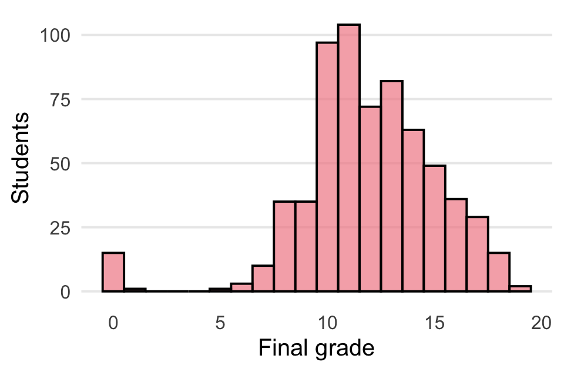

Result Grades cluster between 10 and 14. A handful of students scored 0.

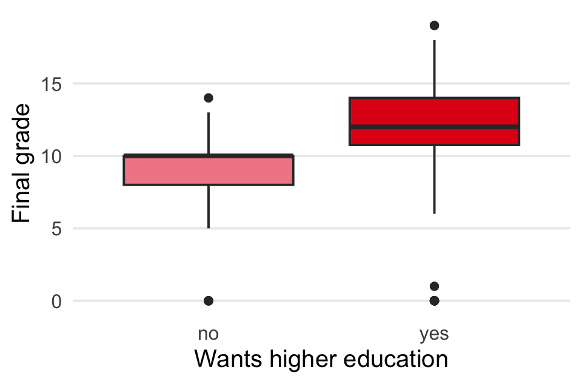

Result Students who plan higher education score higher. **How much** higher, and could it be chance? That’s Part 2.

# The hypothesis-testing approach

Part 2

Is there an effect? How sure are we? · `summary()` · `~ .`

## Reading `summary()`

Concept1 · EDA2 · Hypothesis3 · ML4 · Residuals5 · LassoWrap-up

**Notebook** lines 146–152 the hypothesis-testing approach*run together*

```r
linear_reg() |>
  fit(final_grade ~ higher, data = students) |>
  extract_fit_engine() |>
  summary()
```

|  | Estimate | Std. Error | t value | Pr(>\|t\|) |
| --- | --- | --- | --- | --- |
| (Intercept) | 8.80 | 0.367 | 24.0 | <2e-16 |
| higheryes | 3.48 | 0.388 | 8.96 | <2e-16 |

Also printed: Multiple R-squared 0.110. `extract_fit_engine()` pulls the `lm` object out of the tidymodels wrapper so `summary()` can print it.

Estimate The coefficient: students who want higher education score **3.48 points higher**. The intercept, 8.80, is the mean grade of the “no” students.

Std. Error How uncertain the estimate is. Another sample would give a slightly different 3.48.

t value and p-value t = estimate ÷ standard error: 9 standard errors from zero. The p-value: *if the true effect were 0, how surprising would this be?* Extremely.

## Controlling for everything: `~ .`

Concept1 · EDA2 · Hypothesis3 · ML4 · Residuals5 · LassoWrap-up

**Notebook** lines 160–165 the multivariable model*run together*

```r
linear_reg() |>
  fit(final_grade ~ ., data = students) |>
  extract_fit_engine() |>
  summary()
```

[output not shown]

The 7 features with p < 0.01, out of 67 coefficients.

`higheryes` halves From 3.48 to **1.62**, still significant. Part of the raw difference was study time and past failures travelling with the wish for higher education.

R² rises to 0.41 Sixty-seven coefficients explain 41% of the variation. Each past failure costs about 1.5 points.

Caveat p-values say which features matter for *explaining* these 649 students. They are **no guarantee** the model predicts well for new students.

# The machine learning approach

Part 3

Split · fit · evaluate · `initial_split()` · `augment()` · `metric_set()`

## Two questions, two approaches

Concept1 · EDA2 · Hypothesis3 · ML4 · Residuals5 · LassoWrap-up

Hypothesis testing **Does `higher` matter? How sure are we?**

Coefficients, standard errors, p-values. Uses **all** the data. Part 2.

Machine learning **How well can we predict a grade we haven’t seen?**

Predictions and their error on **new** data. **Splits** the data. Parts 3–5.

Same model. Different question. Different workflow.

## A made-up model, in the notebook

Concept1 · EDA2 · Hypothesis3 · ML4 · Residuals5 · LassoWrap-up

**Notebook** lines 191–212 the notebook's version of "what is a model?"*code together*

```r
sim_model_preds <- function(x1, x2, x3) {
  y <- 1.1 * x1 + 2.2 * x2 + 3.3 * x3
  y
}
```

Lines 192–195: the rule as an R function Three inputs, three coefficients, one output. Nobody fitted it: the numbers are made up, like the grade rule earlier.

Line 201`sim_model_preds(10, 20, 30)`

Plug in1.1 × 10 + 2.2 × 20 + 3.3 × 30 = 11 + 44 + 99

Prediction= 154

Line 209`150 - sim_model_preds(10, 20, 30)`

Residual150 − 154 = −4 actual − predicted: the rule guessed 4 too high

## Why split?

Concept1 · EDA2 · Hypothesis3 · ML4 · Residuals5 · LassoWrap-up

You revise with last year’s exam paper, then sit… last year’s paper again. Is your mark a fair measure of what you learned?

**649 students**all the rows

→

**Training set · 486 rows (75%)**the model is fitted here

**Test set · 163 rows (25%)**locked away; opened only to score the finished model

Overfitting Scored on its own training rows, a model flatters itself: it has partly memorised their quirks. The test set is a fresh exam. A big **gap** between the two scores is the warning sign.

## The split, piece by piece

Concept1 · EDA2 · Hypothesis3 · ML4 · Residuals5 · LassoWrap-up

**Notebook** lines 218–225 type the three steps under the three comments*code together*

set.seed(123) students_split <- initial_split(students, prop = 0.75) students_train <- training(students_split) students_test <- testing(students_split)

1. **Make the random draw repeatable**, so your numbers match the slides.
2. **Decide which rows go where.** A *split object*: a note of which rows are which, **not yet two tables**.
3. **The share for training.** 75% here; 70–80% is typical.
4. **Pull out the training table**: 486 rows.
5. **Pull out the test table**: 163 rows. Don’t touch it until the model is finished.

## Fit and predict

Concept1 · EDA2 · Hypothesis3 · ML4 · Residuals5 · LassoWrap-up

**Notebook** lines 233–235 the "Code here" chunk: fit on the training set*code together*

mv_model <- linear_reg() |> fit(final_grade ~ ., data = students_train) mv_model |> augment(new_data = students_test)

1. **Fit on the training rows only**, and save the model. This is the line to type at line 234.
2. **Predict.** `augment()` takes a table and gives it back with two new columns. It appears in the evaluation chunk next.

| final_grade | school | … | .pred | .resid |
| --- | --- | --- | --- | --- |
| 11 | GP | … | 13.4 | −2.36 |
| 12 | GP | … | 11.0 | 0.99 |

`.pred` the prediction for each row · `.resid` actual − prediction

## Evaluate

Concept1 · EDA2 · Hypothesis3 · ML4 · Residuals5 · LassoWrap-up

**Notebook** lines 246–256 given in the notebook: run it, training set then test set*run together*

reg_metrics <- metric_set(rsq, rmse) mv_model |> augment(new_data = students_test) |> reg_metrics(truth = final_grade, estimate = .pred)

1. **Bundle the metrics** into one function. `rsq` is R², `rmse` is RMSE.
2. **Which column is the truth**: the real grade.
3. **Which column is the guess**: the `.pred` column that `augment()` just added.

The notebook runs it twice: once with `new_data = students_train`, once with `students_test`. Compare the two tables.

## Part 3 together: what you should see

```r
set.seed(123)
students_split <- initial_split(students, prop = 0.75)
students_train <- training(students_split)
students_test  <- testing(students_split)

mv_model <- linear_reg() |>
  fit(final_grade ~ ., data = students_train)

reg_metrics <- metric_set(rsq, rmse)

mv_model |>
  augment(new_data = students_test) |>
  reg_metrics(truth = final_grade, estimate = .pred)
```

Notebook lines 218–256 as one pipeline: split the students, fit the full linear model on the training rows, then score it on the test rows. Each click shows the output of the next step.

`initial_split()` records which rows are which. Printing the split object shows the sizes: 486 training, 163 test, 649 in total. `training()` and `testing()` turn it into two tibbles.

```
<Training/Testing/Total>
<486/163/649>
```

`fit()` runs least squares on the 486 training rows. `tidy()` shows the coefficients it found: one row each, 68 in all.

```
# A tibble: 68 × 5
  term        estimate std.error statistic p.value
  <chr>          <dbl>     <dbl>     <dbl>   <dbl>
1 (Intercept)    7.45      2.38       3.13 0.00190
2 schoolMS      -0.998     0.323     -3.09 0.00216
3 sexM          -0.549     0.294     -1.87 0.0626
4 age            0.154     0.120      1.29 0.198
# ℹ 64 more rows
```

`metric_set()` makes a new function that computes both metrics at once.

```
A metric set, consisting of:
- `rsq()`, a numeric metric  | direction:
maximize
- `rmse()`, a numeric metric | direction:
minimize
```

`augment()` returns the test table with two new columns: `.pred`, the predicted grade, and `.resid`, how far off it was. (Only those and the grade are shown here.)

```
# A tibble: 163 × 3
  final_grade .pred .resid
        <dbl> <dbl>  <dbl>
1          11  13.4 -2.36
2          11  13.0 -1.98
3          12  11.0  0.988
4          17  15.6  1.39
# ℹ 159 more rows
```

`reg_metrics()` compares the two columns. On students the model has never seen: R² 0.21, RMSE 3.04 grade points.

```
# A tibble: 2 × 3
  .metric .estimator .estimate
  <chr>   <chr>          <dbl>
1 rsq     standard       0.211
2 rmse    standard       3.04
```

On the training set the same three lines give R² 0.446 and RMSE 2.37.

## Part 3: training versus test

Concept1 · EDA2 · Hypothesis3 · ML4 · Residuals5 · LassoWrap-up

**Notebook** lines 258–260 classroom discussion: how can we interpret these results?*run together*

R² share of variation explained

Training**0.446**

Test**0.211**

RMSE typical miss, in grade points

Training**2.37**

Test**3.04**

Is this model good? Better than guessing the mean. But on new students it explains 21% of the variation, not 45%, and a typical prediction is 3 grade points off. The gap is **overfitting**.

Why? 67 coefficients fitted on 486 rows. Many describe noise. Could we keep only the useful ones? **Part 5.**

# Where do we make errors?

Part 4

Residual plots · `.pred` against `.resid`

## Residual plots: what good looks like

Concept1 · EDA2 · Hypothesis3 · ML4 · Residuals5 · LassoWrap-up

**Notebook** lines 268–324 run the four chunks: simulated data, its scatter, its residual plot, then ours*run together*

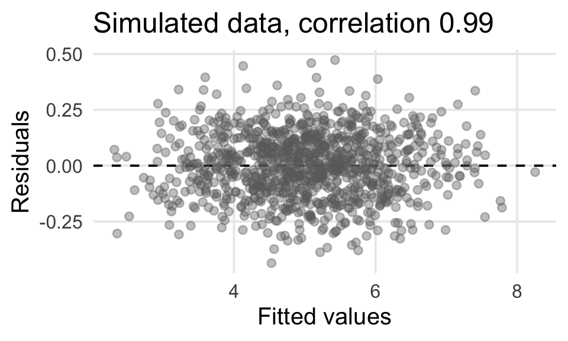

A shapeless cloud around zero Nothing left to explain. This is what a well-fitting model leaves behind.

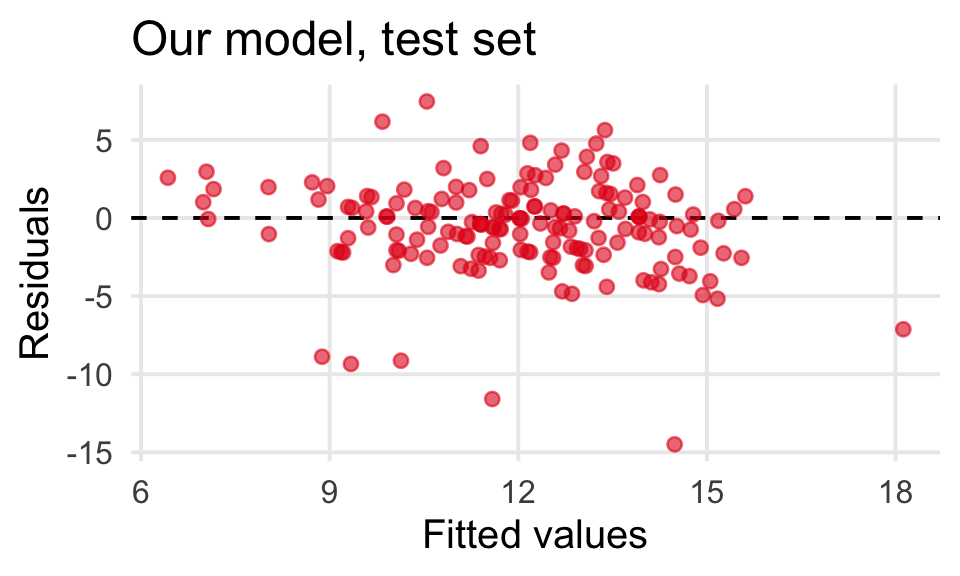

Wide, and with a pattern A diagonal streak at the bottom left. **Any pattern is something the model missed.**

## The residual plot, piece by piece

Concept1 · EDA2 · Hypothesis3 · ML4 · Residuals5 · LassoWrap-up

**Notebook** lines 302–324 the same plot twice: simulated data, then our model on the test set*code together*

mv_model |> augment(new_data = students_test) |> ggplot(aes(.pred, .resid)) + geom_hline(yintercept = 0, linetype = "dashed") + geom_point()

1. **x: the prediction** for each student, from `augment()`.
2. **y: the residual**, actual − predicted. Above the line the model guessed too low, below it too high.
3. **The “no error” line.** A good model leaves a shapeless cloud around it.

`augment()` first, then `ggplot()`: the two columns only exist once the model has been applied. Line 326, the action point: why does the simulated data look so much better?

# Lasso: a penalty for every coefficient

Part 5

Regularisation · λ · hyperparameters · `penalty` · `mixture = 1` · `set_engine("glmnet")`

## The problem with “everything”

Concept1 · EDA2 · Hypothesis3 · ML4 · Residuals5 · LassoWrap-up

67 coefficients, 486 training rows The model is *free* to use every coefficient, so it does, including the ones that only describe noise in the training rows. R² 0.45 in training, 0.21 on new students.

How would you stop a model from using coefficients it doesn’t need?

Option 1: by hand Drop the features with large p-values and refit. Slow, subjective, and the p-values came from the model you’re about to change.

Option 2: inside the algorithm Change the score the algorithm minimises so that **every coefficient has a cost**. That’s the **lasso**.

## Charge rent for every coefficient

Concept1 · EDA2 · Hypothesis3 · ML4 · Residuals5 · LassoWrap-up

Lasso minimises RSS + λ · Σ |βⱼ|

1. **Fit the data**, as before. OLS minimised this and nothing else.
2. **Lambda: the price per unit of coefficient.** You choose it. The notebook calls it `penalty`.
3. **The total size of all coefficients**, signs ignored. The bill.

Say λ = 0.1and three coefficients: 1.8, −1.4, 0.05

Total size|1.8| + |−1.4| + |0.05| = 3.25

The bill0.1 × 3.25 = 0.325 added to the RSS

Drop the 0.05bill falls by 0.005 if the RSS rises by less than that, the model is better off without it

## Turning the dial

Concept1 · EDA2 · Hypothesis3 · ML4 · Residuals5 · LassoWrap-up

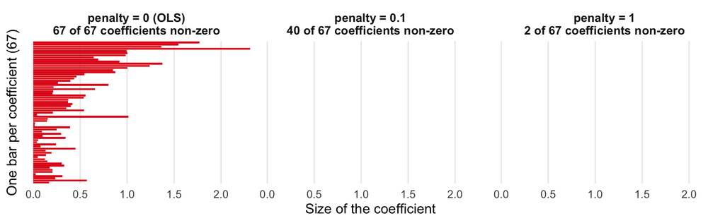

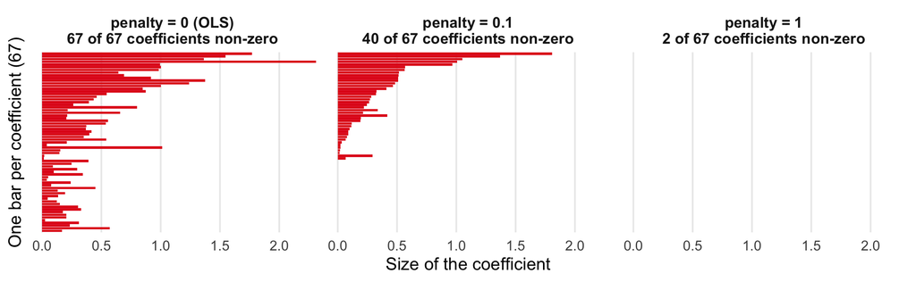

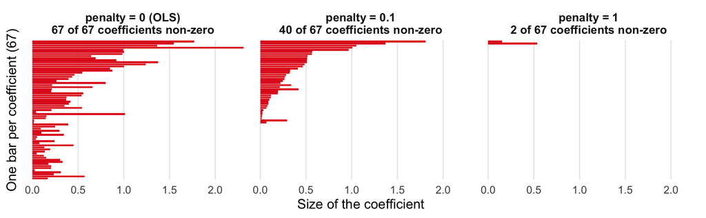

λ = 0 No rent. Back to OLS: all 67 coefficients in use, and the overfitting from Part 3.

λ = 0.1 Coefficients shrink, and 27 of them hit **exactly zero**. Feature selection built into the fitting.

λ = 1 Only 2 survive. Dial it up further and everything goes to zero: the model predicts the mean for everyone.

## Why *exactly* zero?

Concept1 · EDA2 · Hypothesis3 · ML4 · Residuals5 · LassoWrap-up

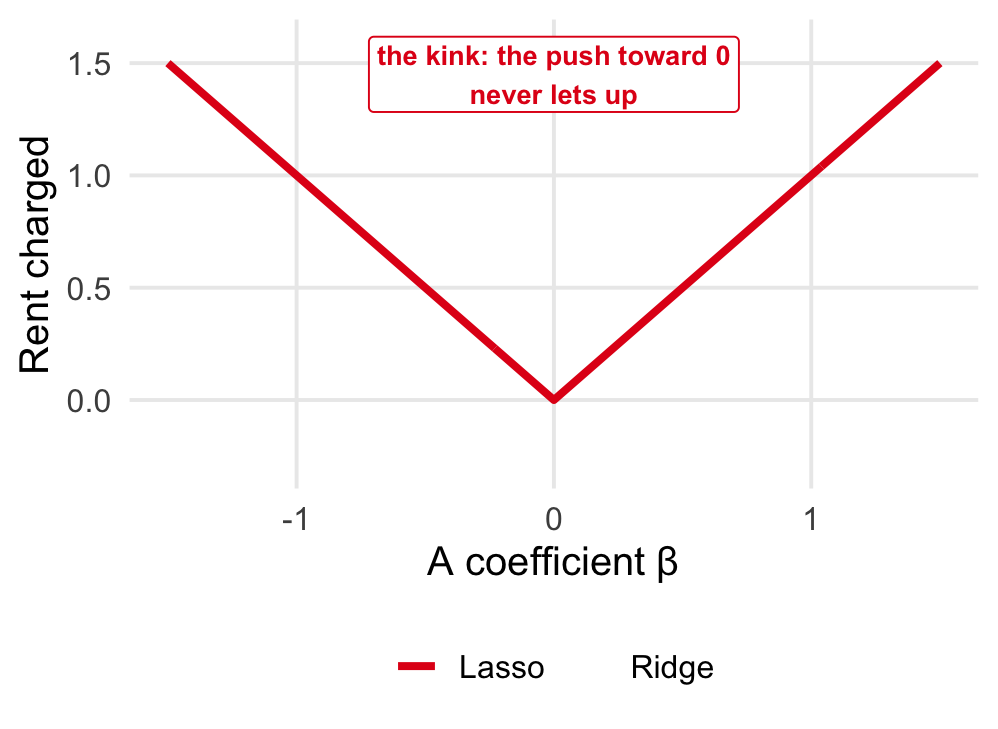

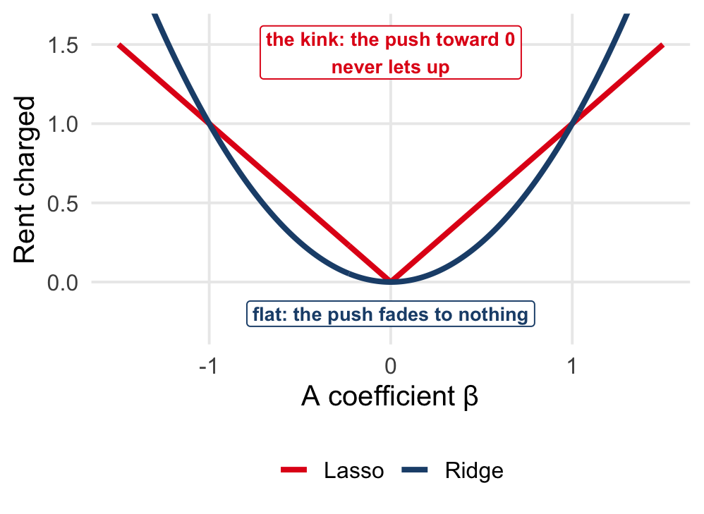

Two forces on each coefficient The **data** pull it away from zero, with a force that weakens as the fit improves. The **penalty** pushes it back toward zero.

The lasso’s push is constant |β| has the same slope everywhere, so the push is **λ, whatever the coefficient’s size**. If the data’s pull is weaker than λ, the coefficient is pinned at **exactly 0**.

Ridge, for contrast β² goes flat near zero, so its push fades as the coefficient shrinks: coefficients get tiny but **never reach zero**. `mixture = 1` picks the lasso, `0` the ridge.

## Parameters and hyperparameters

Concept1 · EDA2 · Hypothesis3 · ML4 · Residuals5 · LassoWrap-up

Parameters The **βs**, 67 of them. Chosen **by the algorithm**, from the data, by minimising the score. Inside the machine.

Hyperparameters **λ** (`penalty`) and `mixture`. Chosen **by you**, before fitting. A knob on the outside of the machine.

Why can’t the data choose λ? Any λ > 0 makes the *training* fit worse, so the algorithm would always pick 0. Instead: try several values, score each on data the model hasn’t seen, keep the best. Today’s bonus does it by hand; Lab 5 automates it.

## Lasso in code

Concept1 · EDA2 · Hypothesis3 · ML4 · Residuals5 · LassoWrap-up

**Notebook** lines 336–341 Step 1: run it together. Steps 2–5 are yours*run together*

lasso_model <- linear_reg(penalty = 0.1, mixture = 1) |> set_engine("glmnet") |> fit(final_grade ~ ., data = students_train) tidy(lasso_model)

1. **λ.** The rent per unit of coefficient. 0.1 to start.
2. **Which penalty.** 1 is the lasso, 0 is the ridge, in between mixes them.
3. **Which package computes.** The default, `lm`, can’t penalise; `glmnet` can.
4. **Step 2, yours:** `tidy()` gives one row per coefficient. Filter out the zeros.

Everything after `fit()` is unchanged: `augment()` and `reg_metrics()` work exactly as in Part 3, so Step 4 is copy and paste.

## Exercises: Part 5

Part 5 · lasso · notebook lines 347–377

1. **Line 348:** `tidy()` the model and keep the non-zero coefficients. How many survived? Which is the largest?
2. **Line 356:** the bar plot of coefficient sizes
3. **Line 364:** test-set R² and RMSE with `reg_metrics`. Better or worse than Part 3?
4. **Line 376, bonus:** try other penalties (0.01, 0.3, 1). Which gives the lowest test RMSE?

Syntax you need

```r
tidy(lasso_model) |>
  filter(estimate != 0)

tidy(lasso_model) |>
  filter(term != "(Intercept)") |>
  ggplot(aes(abs(estimate), fct_reorder(term, abs(estimate)),
             fill = estimate > 0)) +
  geom_col() + theme_bar() + scale_fill_jama()

lasso_model |>
  augment(new_data = students_test) |>
  reg_metrics(truth = final_grade, estimate = .pred)
```

**Stuck?**

- *could not find function “fct_reorder”*: run the setup chunk (it’s in the tidyverse)
- Bonus: copy Step 1 with a new `penalty`, then Step 4 again. The solutions have a `map()` version

## Solutions: Part 5

```r
lasso_model <-
  linear_reg(penalty = 0.1, mixture = 1) |>
  set_engine("glmnet") |>
  fit(final_grade ~ ., data = students_train)

tidy(lasso_model) |>
  filter(estimate != 0)

lasso_model |>
  augment(new_data = students_test) |>
  reg_metrics(truth = final_grade, estimate = .pred)
```

Fit a lasso with penalty 0.1 on the training rows, look at which coefficients survived, then score it on the test rows.

Same `fit()` as before, with a price on coefficients and `glmnet` doing the work. Counting the coefficients: 27 were set to exactly zero, 41 (including the intercept) survived.

```
# A tibble: 2 × 2
  zero      n
  <lgl> <int>
1 FALSE    41
2 TRUE     27
```

`tidy()` lists every coefficient; `filter()` keeps the non-zero ones. Sorted by size here: wanting higher education, past failures and school support matter most.

```
# A tibble: 40 × 3
  term           estimate penalty
  <chr>             <dbl>   <dbl>
1 higheryes         1.81      0.1
2 failures         -1.37      0.1
3 schoolsupyes     -1.05      0.1
4 feduNone          1.01      0.1
5 schoolMS         -0.966     0.1
6 traveltime>1hr   -0.568     0.1
# ℹ 34 more rows
```

Exactly the evaluation code from Part 3. On the test set: R² 0.24 and RMSE 2.95, against 0.21 and 3.04 for the model with all 67 coefficients.

```
# A tibble: 2 × 3
  .metric .estimator .estimate
  <chr>   <chr>          <dbl>
1 rsq     standard       0.240
2 rmse    standard       2.95
```

Step 2 shows the 6 largest coefficients, sorted with `arrange(desc(abs(estimate)))`, to fit the slide. The notebook prints all 41 in the original order.

## Part 5: did the penalty help?

Concept1 · EDA2 · Hypothesis3 · ML4 · Residuals5 · LassoWrap-up

**Notebook** lines 347–365 Steps 2–4*your turn*

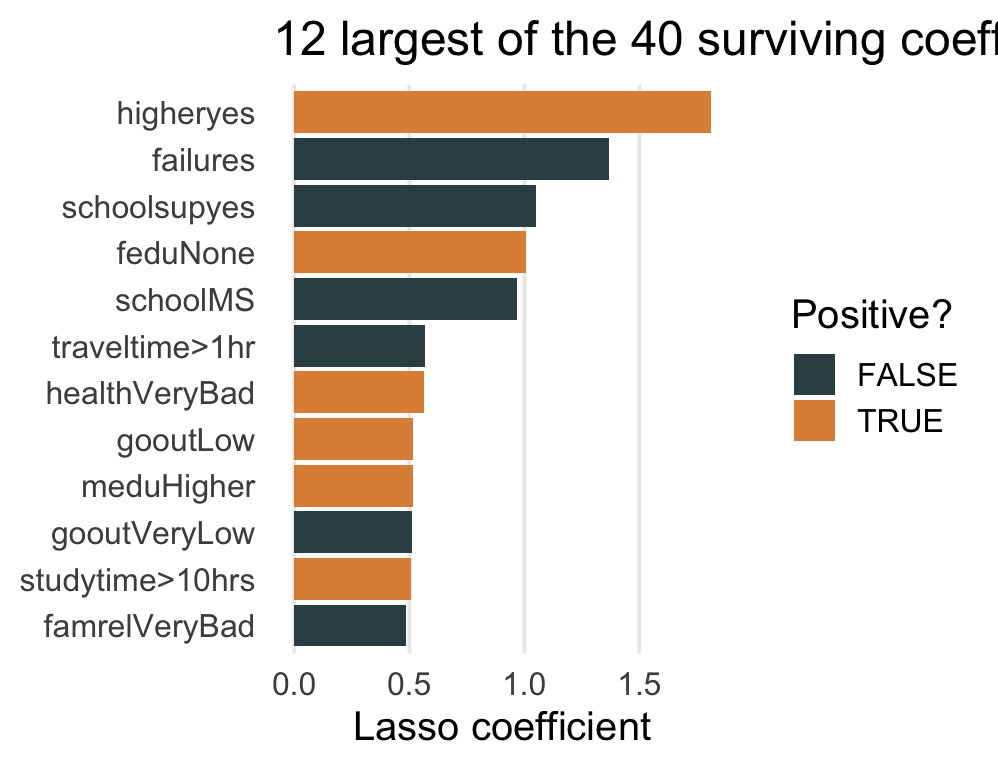

Test set 163 students the models never saw

|  | Coefficients | R² | RMSE |
| --- | --- | --- | --- |
| Linear, `~ .` | 67 | 0.211 | 3.04 |
| Lasso, penalty 0.1 | 40 | 0.240 | 2.95 |

Result A simpler model that predicts new students slightly better. 27 coefficients gone, nothing lost. That’s **regularisation**.

## Bonus: turning the dial by hand

Concept1 · EDA2 · Hypothesis3 · ML4 · Residuals5 · LassoWrap-up

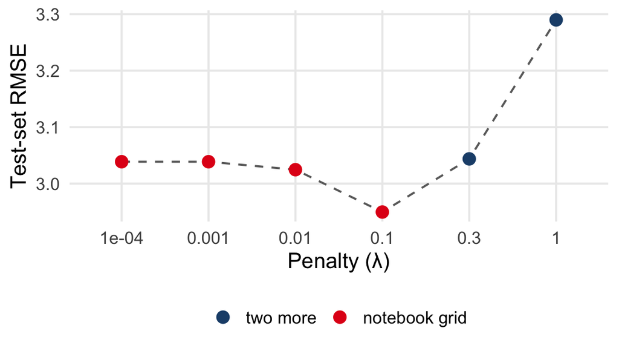

The notebook’s grid 0.0001, 0.001 and 0.01 are all about 3.03, hardly different from plain OLS. **0.1 is best** at 2.95.

Two more, past the grid 0.3 is worse again (3.04, with only 14 coefficients) and 1 is bad (3.29, with 2). A bowl again, this time scored on test data.

That’s tuning Turn the knob, score on data the model hasn’t seen, keep the best setting. Lab 5 automates it.

## Summary

Concept1 · EDA2 · Hypothesis3 · ML4 · Residuals5 · LassoWrap-up

**1**Ordinary least squares picks the line with the **smallest sum of squared residuals**. A coefficient is the change in the prediction when its feature rises by one unit, other things equal

**2****Split first.** Fit on the training set, score on the test set. The gap between the two scores is overfitting

**3**`linear_reg() |> fit()` · `augment()` · `metric_set(rsq, rmse)` is the workflow for every model from now on

**4**The lasso adds a **price per coefficient**. λ is a hyperparameter you set; coefficients that aren't worth the rent go to exactly zero

**Question:** which of the 30 features would you have bet on before today? Did the lasso agree?

## Further reading

- The completed notebook goes up after class.
- [*An Introduction to Statistical Learning*](https://www.statlearning.com): chapter 3 (linear regression) and section 6.2 (the lasso). Free PDF.
- [*Tidy Modeling with R*](https://www.tmwr.org): the `parsnip` and `yardstick` chapters.
- The [tidymodels reference sheet](https://rstudio.github.io/cheatsheets/tidymodels.pdf).

Week 4 Classification: predicting categories instead of numbers